# Financial Statements Analysis

Group 1

10 April, 2020

# 1 Group 1 members

This group assignment was developed by the following students:

[output not shown]

# 2 Situation

The objective is to give you first hand experience in unstructured data analysis

# 3 Analysis

## 3.1 Amazon

## 3.2 Facebook

## 3.3 Fitbit

According to the text analysis performed on the annual reports from the last five years from 2016 to 2020, Fitbit has gone through significant business development and growth. Fitbit has released 15 different products (13 fitness trackers, 1 earbuds and 1 scale) over the last five year period, which indicates that they have focused their business to develop new products in order to attract more users. This is shown in the list of 50 most frequent words used throughout five reports from 2016 to 2020 (highlighted the relevant terms in Appendix 1) that conveys how much emphasis Fitbit has put on the product development. Then, we have conducted more detailed clustering reports for each year and investigated more in detail to see why certain terms were more distinct than the others. In the 2016 report (Appendix 2), there were certain terms that were specific for the cluster 1 (2016) that stood out: connect, fit, stock and fitbit. This is because Fitbit acquired a fitness coaching app called FitStar in March of 2015 which connected many of the users who wanted to stay fit through training features provided through the subscription service (Pai, 2015). It is also worthwhile to note that Fitbit “filed for IPO with a NYSE listing” (Avi, Jani, & Bidkar, 2019) and entered the stock market under the name of “FIT” in 2015. To justify the specific terms outstanding in the 2020 report (Appendix 3), fit, merger, google, covid and outbreak, Fitbit’s stock market (NYSE: FIT) has been affected by the acquirement by Google and the subsequent merger of the company announced in 2019 and not to mention COVID-19 outbreak in 2020 that will significantly affect the stock market. Due to the page restriction of this assignment, the rest of the clustering reports are in Appendix 4.

## 3.4 Intel Corporation

## 3.5 Netflix

# 4 List of files for each company

- *Amazon*

```
## [1] "data/Amazon/Amazon_annual_report2013.pdf"
## [2] "data/Amazon/Amazon_annual_report2014.pdf"
## [3] "data/Amazon/Amazon_annual_report2015.pdf"
## [4] "data/Amazon/Amazon_annual_report2016.pdf"
## [5] "data/Amazon/Amazon_annual_report2018.pdf"
```

- *Facebook*

```
## [1] "data/Facebook/Facebook_annual_report2013.pdf"
## [2] "data/Facebook/Facebook_annual_report2014.pdf"
## [3] "data/Facebook/Facebook_annual_report2015.pdf"
## [4] "data/Facebook/Facebook_annual_report2016.pdf"
## [5] "data/Facebook/Facebook_annual_report2017.pdf"
## [6] "data/Facebook/Facebook_annual_report2018.pdf"
```

- *Fitbit*

```
## [1] "data/Fitbit/2016-10k-annual-report.pdf"
## [2] "data/Fitbit/2017-10k-annual-report.pdf"
## [3] "data/Fitbit/2018-10k-annual-report.pdf"
## [4] "data/Fitbit/2019-10k-annual-report.pdf"
## [5] "data/Fitbit/2020-10k-annual-report.pdf"
```

- *Intel*

```
##  [1] "data/Intel/Intel_2010_Annual_Report_and_Form_10-K.pdf"
##  [2] "data/Intel/Intel_2011_Annual_Report_and_Form_10-K.pdf"
##  [3] "data/Intel/Intel_2012_Annual_Report_and_Form_10-K.pdf"
##  [4] "data/Intel/Intel_2013_Annual_Report_and_Form_10-K.pdf"
##  [5] "data/Intel/Intel_2014_Annual_Report_and_Form_10-K.pdf"
##  [6] "data/Intel/Intel_2015_Annual_Report_and_Form_10-K.pdf"
##  [7] "data/Intel/Intel_2016_Annual_Report_and_Form_10-K.pdf"
##  [8] "data/Intel/Intel_2017_Annual_Report_and_Form_10-K.pdf"
##  [9] "data/Intel/Intel_2018_Annual_Report_and_Form_10-K.pdf"
## [10] "data/Intel/Intel_2019_Annual_Report_and_Form_10-K.pdf"
```

- *Netflix*

```
## [1] "data/Netflix/Netflix_annual_report2013.pdf"
## [2] "data/Netflix/Netflix_annual_report2014.pdf"
## [3] "data/Netflix/Netflix_annual_report2015.pdf"
## [4] "data/Netflix/Netflix_annual_report2016.pdf"
## [5] "data/Netflix/Netflix_annual_report2017.pdf"
## [6] "data/Netflix/Netflix_annual_report2018.pdf"
```

# 5 Document stats

## 5.1 Amazon

**Below we look at the first 10 terms:**

```
## <<TermDocumentMatrix (terms: 10, documents: 5)>>
## Non-/sparse entries: 49/1
## Sparsity           : 2%
## Maximal term length: 11
## Weighting          : term frequency (tf)
## Sample             :
##              Docs
## Terms         Amazon_annual_report2013.pdf Amazon_annual_report2014.pdf
##   aaa                                    1                            1
##   aaarated                               3                            3
##   ability                               14                           14
##   able                                  17                           18
##   absolute                               8                            9
##   accelerate                             1                            1
##   accelerated                           17                           20
##   accept                                 3                            3
##   acceptable                             6                            6
##   accepted                               7                            7
##              Docs
## Terms         Amazon_annual_report2015.pdf Amazon_annual_report2016.pdf
##   aaa                                    1                            1
##   aaarated                               3                            3
##   ability                               14                           13
##   able                                  18                           16
##   absolute                              15                           11
##   accelerate                             2                            1
##   accelerated                           20                           16
##   accept                                 3                            4
##   acceptable                             6                            6
##   accepted                               7                            7
##              Docs
## Terms         Amazon_annual_report2018.pdf
##   aaa                                    0
##   aaarated                               4
##   ability                               16
##   able                                  17
##   absolute                              11
##   accelerate                             2
##   accelerated                           16
##   accept                                 3
##   acceptable                             7
##   accepted                               5
```

**File content:**

[output not shown]

**The total counts for those words:**

```
##               Docs
## Terms          Amazon_annual_report2013.pdf Amazon_annual_report2014.pdf
##   assets                                108                          120
##   billion                                76                           89
##   cash                                  192                          233
##   consolidated                          108                          109
##   costs                                  93                          114
##   customers                             118                          109
##   december                              181                          196
##   financial                             141                          150
##   including                             128                          130
##   income                                155                          169
##   may                                   159                          174
##   million                               202                          190
##   net                                   198                          212
##   operating                             145                          155
##   related                                94                          114
##   sales                                 170                          178
##   services                              135                          135
##   tax                                   182                          201
##               Docs
## Terms          Amazon_annual_report2015.pdf Amazon_annual_report2016.pdf
##   assets                                124                          116
##   billion                               108                          113
##   cash                                  210                          213
##   consolidated                          104                          106
##   costs                                 128                          124
##   customers                              97                           90
##   december                              191                          205
##   financial                             144                          135
##   including                             132                          126
##   income                                182                          180
##   may                                   175                          175
##   million                               186                          191
##   net                                   205                          191
##   operating                             155                          158
##   related                               115                          116
##   sales                                 190                          174
##   services                              139                          136
##   tax                                   204                          219
##               Docs
## Terms          Amazon_annual_report2018.pdf
##   assets                                113
##   billion                               157
##   cash                                  252
##   consolidated                          113
##   costs                                 109
##   customers                             103
##   december                              199
##   financial                             150
##   including                             121
##   income                                158
##   may                                   175
##   million                               150
##   net                                   189
##   operating                             147
##   related                                92
##   sales                                 170
##   services                              134
##   tax                                   239
```

**The frequency for those words :**

```
##         cash          tax          net     december      million
##         1100         1045          995          972          919
##        sales          may       income    operating    financial
##          882          858          844          760          720
##     services    including       assets        costs      billion
##          679          637          581          568          543
## consolidated      related    customers
##          540          531          517
```

## 5.2 Facebook

**Below we look at the first 10 terms:**

```
## <<TermDocumentMatrix (terms: 10, documents: 6)>>
## Non-/sparse entries: 57/3
## Sparsity           : 5%
## Maximal term length: 11
## Weighting          : term frequency (tf)
## Sample             :
##              Docs
## Terms         Facebook_annual_report2013.pdf
##   aada                                     0
##   abandonment                              3
##   ability                                 56
##   able                                    23
##   abroad                                   3
##   absolute                                 0
##   accelerated                              8
##   acceptance                               4
##   accepted                                 8
##   access                                  29
##              Docs
## Terms         Facebook_annual_report2014.pdf
##   aada                                     1
##   abandonment                              7
##   ability                                 52
##   able                                    21
##   abroad                                   3
##   absolute                                 1
##   accelerated                              6
##   acceptance                               4
##   accepted                                 8
##   access                                  25
##              Docs
## Terms         Facebook_annual_report2015.pdf
##   aada                                     1
##   abandonment                              5
##   ability                                 58
##   able                                    21
##   abroad                                   3
##   absolute                                 1
##   accelerated                             12
##   acceptance                               4
```

[output cut: 23 more lines]

```
##   acceptance                               6
##   accepted                                10
##   access                                  22
##              Docs
## Terms         Facebook_annual_report2018.pdf
##   aada                                     2
##   abandonment                              0
##   ability                                 62
##   able                                    22
##   abroad                                   5
##   absolute                                 2
##   accelerated                              6
##   acceptance                               6
##   accepted                                10
##   access                                  35
```

**File content:**

[output not shown]

[output cut: 19 more lines]

[output not shown]

**The total counts for those words:**

```
##               Docs
## Terms          Facebook_annual_report2013.pdf
##   addition                                 82
##   also                                     78
##   assets                                  111
##   billion                                  70
##   business                                164
##   cash                                    129
##   certain                                  82
##   class                                   153
##   common                                  148
##   compensation                             71
##   consolidated                             95
##   data                                    132
##   december                                211
##   facebook                                234
##   financial                               218
##   including                               104
##   income                                  177
##   increase                                110
##   information                              83
##   may                                     293
##   million                                 153
##   mobile                                  169
##   net                                     148
##   number                                   86
##   operations                              101
##   period                                   85
##   plan                                     40
##   products                                156
##   related                                  89
##   results                                 109
##   revenue                                 210
##   securities                              116
##   shares                                   89
##   statements                              128
##   stock                                   203
##   subject                                  75
##   tax                                     146
##   total                                    71
```

[output cut: 209 more lines]

```
##   products                                242
##   related                                 112
##   results                                 121
##   revenue                                 210
##   securities                              176
##   shares                                  233
##   statements                              152
##   stock                                   233
##   subject                                 136
##   tax                                     370
##   total                                    77
##   user                                    168
##   users                                   137
##   value                                   106
##   will                                    209
```

**The frequency for those words**

```
##          may    financial        stock          tax      revenue
##         1987         1506         1445         1404         1300
##     december     products       income        class       common
##         1270         1212         1123         1090         1042
##         cash     business     facebook       shares         user
##         1012          982          918          908          893
##         data          net        users         will   statements
##          887          871          869          864          851
##   securities       assets    including      results compensation
##          849          805          715          699          679
##      million consolidated       mobile     increase      related
##          677          655          648          645          630
##   operations       number      subject        value      certain
##          590          574          574          571          556
##        total      billion  information     addition         also
##          541          540          530          528          511
##       period         plan
##          510          500
```

Find association with the *“revenue”,“client”,“gross”,“net”* at 85%:

```
## $revenue
##     contracted         square       majority  strengthening  substantially
##           0.99           0.99           0.96           0.95           0.95
##        consume         delays    fundraising         hiring   construction
##           0.94           0.94           0.94           0.93           0.92
##         earned         office       property       although       building
##           0.92           0.92           0.91           0.90           0.90
##    communities considerations          chain     charitable         tables
##           0.90           0.90           0.89           0.89           0.89
##         higher      principal          allow      buildings  functionality
##           0.88           0.88           0.87           0.87           0.87
##    interactive       progress      customers           fasb          known
##           0.87           0.87           0.86           0.86           0.86
##        capture      processes
##           0.85           0.85
##
## $client
## numeric(0)
##
## $gross
##        enforcement              civil           criminal
##               1.00               0.97               0.97
##         difficulty          eliminate         immaterial
##               0.97               0.97               0.97
##           imposing            limited          sanctions
##               0.97               0.97               0.97
##       successfully           announce             expose
##               0.97               0.96               0.96
##             impose           platform          adversely
##               0.96               0.96               0.95
##        adjustments       distribution         obligation
##               0.94               0.94               0.94
##        capitalized            prevent             quoted
##               0.93               0.93               0.93
##       specifically                tax        translation
##               0.93               0.93               0.93
##               aada acquisitionrelated            collect
##               0.92               0.92               0.92
##          depending          favorable              forms
##               0.92               0.92               0.92
```

[output cut: 113 more lines]

```
##              0.97              0.96              0.95              0.95
##              incs   postacquisition         reduction           perform
##              0.93              0.93              0.92              0.91
##            almost              need          reliance             sales
##              0.90              0.90              0.90              0.90
##        completion          activity             click             ended
##              0.89              0.88              0.88              0.88
##              send           undrawn             facts              seek
##              0.88              0.88              0.87              0.87
##             cards       identifying             small          congress
##              0.86              0.86              0.86              0.85
##       differences           earnout      historically           methods
##              0.85              0.85              0.85              0.85
##       potentially        sharebased
##              0.85              0.85
```

## 5.3 Fitbit

**Below we look at the first 10 terms:**

```
## <<TermDocumentMatrix (terms: 10, documents: 5)>>
## Non-/sparse entries: 48/2
## Sparsity           : 4%
## Maximal term length: 11
## Weighting          : term frequency (tf)
## Sample             :
##              Docs
## Terms         2016-10k-annual-report.pdf 2017-10k-annual-report.pdf
##   ability                             63                         65
##   able                                32                         33
##   abroad                               3                          3
##   absolute                             3                          5
##   accelerate                           0                          2
##   accelerated                          7                         13
##   accept                               1                          0
##   acceptable                           5                          5
##   acceptance                           6                          6
##   accepted                             3                          8
##              Docs
## Terms         2018-10k-annual-report.pdf 2019-10k-annual-report.pdf
##   ability                             78                         76
##   able                                29                         29
##   abroad                               3                          3
##   absolute                             5                          5
##   accelerate                           1                          1
##   accelerated                         16                         11
##   accept                               2                          1
##   acceptable                           4                          4
##   acceptance                           9                         10
##   accepted                             7                          6
##              Docs
## Terms         2020-10k-annual-report.pdf
##   ability                             78
##   able                                31
##   abroad                               3
##   absolute                             1
##   accelerate                           2
##   accelerated                          9
##   accept                               1
##   acceptable                           4
##   acceptance                          11
##   accepted                             8
```

**File content:**

[output not shown]

**The total counts for those words:**

```
##               Docs
## Terms          2016-10k-annual-report.pdf 2017-10k-annual-report.pdf
##   also                                104                         99
##   assets                              175                        172
##   business                            157                        153
##   cash                                162                        197
##   certain                              72                        107
##   class                               160                        143
##   common                              243                        207
##   company                             343                        271
##   companys                             92                         76
##   consolidated                        109                        114
##   contents                            106                        104
##   costs                               129                        128
##   data                                124                        116
##   december                            220                        212
##   devices                             119                        121
##   expense                             115                        120
##   expenses                            143                        136
##   fair                                133                        116
##   financial                           245                        298
##   fitbit                              285                        224
##   future                              135                        148
##   health                              121                        118
##   including                           138                        134
##   income                              182                        194
##   liabilities                          95                         97
##   loss                                106                        121
##   market                              130                        126
##   may                                 290                        329
##   million                             310                        288
##   net                                 192                        207
##   new                                 105                        115
##   operating                           185                        199
##   period                               92                         82
##   product                             115                        105
##   products                            315                        334
##   related                             119                        123
##   results                             146                        149
##   revenue                             224                        219
```

[output cut: 95 more lines]

```
##   product                             118
##   products                            330
##   related                             148
##   results                             156
##   revenue                             267
##   sales                               160
##   securities                          117
##   services                            174
##   statements                          158
##   stock                               354
##   table                               127
##   tax                                 170
##   users                               174
##   value                               170
##   will                                128
```

**The frequency for those words**

```
##          may        stock     products      company    financial
##         1716         1683         1648         1599         1561
##      million      revenue     december       common       fitbit
##         1561         1259         1119         1072         1069
##          net    operating          tax         cash        users
##         1050         1037         1032          989          981
##       assets       income     services     business        class
##          914          893          866          822          807
##        value       future      results        sales    including
##          792          778          767          738          705
##         will   statements        costs     expenses       market
##          692          687          677          670          656
##      related      devices      expense        table         loss
##          648          631          624          618          616
##          new consolidated         data         fair       health
##          612          609          602          592          580
##      product   securities         also     contents  liabilities
##          568          548          537          535          524
##       period      certain     companys
##          512          506          504
```

Find association with the *“revenue”,“client”,“gross”,“net”* at 85%:

```
## $revenue
##              ending         represented            alleging
##                1.00                1.00                0.99
##             country            impacted            americas
##                0.99                0.99                0.98
##         arbitration             focused           francisco
##                0.98                0.98                0.98
##          investment            shipping           consumers
##                0.98                0.98                0.97
##               court              equity               filed
##                0.97                0.97                0.97
##               fines                held          immaterial
##                0.97                0.97                0.97
##                 mix            services              states
##                0.97                0.97                0.97
##           decreased             derived              direct
##                0.96                0.96                0.96
##              motion           penalties           recurring
##                0.96                0.96                0.96
##               state              august              denied
##                0.96                0.95                0.95
##               plans        smartwatches            software
##                0.95                0.95                0.95
##          volatility          calculated             digital
##                0.95                0.94                0.94
##             driving              enable        expectations
##                0.94                0.94                0.94
##               faced                fall               goods
##                0.94                0.94                0.94
##             healthy              issues             ordered
##                0.94                0.94                0.94
##             outside          population            positive
##                0.94                0.94                0.94
##           promoting           publicity      recoverability
##                0.94                0.94                0.94
##              reduce            revenues           solutions
##                0.94                0.94                0.94
##         unfavorable             accrued          amendments
##                0.94                0.93                0.93
##             channel            creating            customer
```

[output cut: 221 more lines]

```
##           0.88           0.88           0.88           0.88           0.88
##      licensing          limit      liquidity         naming        noncash
##           0.88           0.88           0.88           0.88           0.88
##          place    preexisting       purposes       reserves     resolution
##           0.88           0.88           0.88           0.88           0.88
##        results       reviewed      scheduled            srl           step
##           0.88           0.88           0.88           0.88           0.88
##       subpoena       weighted          costs         differ      financial
##           0.88           0.88           0.87           0.87           0.87
##      purchased     adjustment    appropriate        bonuses         course
##           0.87           0.86           0.86           0.86           0.86
##   difficulties   distributors         excess        holiday            law
##           0.86           0.86           0.86           0.86           0.86
##         others       probable      reduction     securities       acquired
##           0.86           0.86           0.86           0.86           0.85
```

## 5.4 Intel Corporation

**Below we look at the first 10 terms:**

```
## <<TermDocumentMatrix (terms: 10, documents: 10)>>
## Non-/sparse entries: 83/17
## Sparsity           : 17%
## Maximal term length: 9
## Weighting          : term frequency (tf)
## Sample             :
##            Docs
## Terms       Intel_2010_Annual_Report_and_Form_10-K.pdf
##   aaaa                                               3
##   abandoned                                          0
##   abatement                                          1
##   abetted                                            0
##   abide                                              1
##   ability                                           32
##   able                                              18
##   abroad                                             0
##   absence                                            4
##   absolute                                           2
##            Docs
## Terms       Intel_2011_Annual_Report_and_Form_10-K.pdf
##   aaaa                                               4
##   abandoned                                          3
##   abatement                                          1
##   abetted                                            0
##   abide                                              1
##   ability                                           25
##   able                                               8
##   abroad                                             0
##   absence                                            4
##   absolute                                           2
##            Docs
## Terms       Intel_2012_Annual_Report_and_Form_10-K.pdf
##   aaaa                                               2
##   abandoned                                          2
##   abatement                                          1
##   abetted                                            1
##   abide                                              1
##   ability                                           26
##   able                                               9
##   abroad                                             0
```

[output cut: 71 more lines]

```
##   abroad                                             1
##   absence                                            1
##   absolute                                           2
##            Docs
## Terms       Intel_2019_Annual_Report_and_Form_10-K.pdf
##   aaaa                                               0
##   abandoned                                          1
##   abatement                                          1
##   abetted                                            0
##   abide                                              0
##   ability                                           30
##   able                                              13
##   abroad                                             1
##   absence                                            2
##   absolute                                           2
```

**File content:**

[output not shown]

[output cut: 67 more lines]

[output not shown]

**The total counts for those words:**

```
##                Docs
## Terms           Intel_2010_Annual_Report_and_Form_10-K.pdf
##   accounting                                            77
##   activities                                            48
##   addition                                              60
##   agreements                                            32
##   also                                                  98
##   amount                                                53
##   amounts                                               47
##   approximately                                         62
##   asset                                                 81
##   assets                                               276
##   average                                               63
##   balance                                               65
##   based                                                104
##   benefit                                               69
##   benefits                                              66
##   billion                                              126
##   business                                             153
##   can                                                   44
##   capital                                               49
##   cash                                                 171
##   certain                                               97
##   changes                                              114
##   common                                               121
##   companies                                             71
##   company                                               46
##   compared                                              68
##   computing                                             77
##   consolidated                                         128
##   continued                                             85
##   corporate                                             57
##   corporation                                          158
##   cost                                                 115
##   costs                                                 83
##   currency                                              59
##   customers                                             60
##   data                                                  71
##   date                                                  62
##   debt                                                 112
```

[output cut: 1425 more lines]

```
##   subject                                               57
##   tax                                                  151
##   taxes                                                 44
##   technologies                                          71
##   technology                                           156
##   total                                                110
##   unit                                                  53
##   use                                                   73
##   using                                                 37
##   value                                                194
##   well                                                  53
##   will                                                  84
##   within                                                63
##   year                                                  91
##   years                                                 95
```

The frequency for those words

```
##         intel     financial        assets         value           net
##          3294          2656          2505          2445          2437
##        equity       million      december      products         stock
##          2424          2349          2344          2315          2092
##   investments        income           may        market          cash
##          2068          2060          1939          1877          1827
##     operating           tax          fair       revenue      business
##          1763          1690          1665          1586          1537
##          plan    statements       billion    technology      interest
##          1477          1465          1443          1421          1304
##         total   corporation        common  consolidated       related
##          1265          1229          1228          1160          1154
##           due     including          debt         group           new
##          1086          1068          1040          1036          1021
##          cost       results       changes         costs   information
##          1010           993           983           979           974
##         based   instruments        losses   liabilities          rate
##           964           950           947           943           938
##           dec          data      millions     customers        period
##           936           927           927           898           890
##       certain       product         notes          also         gains
##           879           876           864           860           856
##      segments         years manufacturing          will         sales
##           853           851           849           844           843
##    operations    investment          loss        shares          note
##           836           807           803           755           754
##    securities          form   performance        higher          risk
##           750           745           736           732           725
##        future          item      platform       benefit      longterm
##           723           717           717           695           694
##     reporting           use      services         plans      increase
##           692           669           667           660           659
##    recognized   significant      deferred    accounting      included
##           658           656           654           652           641
##     primarily         gross       process        amount     incentive
##           637           629           626           624           622
##       include          year     employees      benefits         share
##           620           614           604           603           600
##         price   development      currency    impairment       quarter
##           597           596           592           591           591
##         taxes        method       subject       follows      recorded
##           591           588           580           578           570
##       balance approximately        within      software         lower
##           568           565           565           561           560
##       amounts     continued          part      earnings      purchase
##           559           559           558           557           556
##      exchange       program     companies        result       general
##           555           555           554           550           549
##          well           per           can           see      director
##           546           543           542           541           540
##     computing          date        number     executive    derivative
##           538           536           534           533           532
##      compared         using         asset       factors    agreements
##           530           530           529           528           527
##       company     effective       average       capital         level
##           526           525           518           516           512
##       segment    activities          unit      addition  technologies
##           510           509           507           504           503
##     corporate
##           502
```

Find association with the *“revenue”,“client”,“gross”,“net”* at 85%:

```
## $revenue
## introducing         pay    resolved        weve
##        0.90        0.87        0.87        0.86
##
## $client
##   helped   africa    chief revenues
##     0.98     0.92     0.86     0.86
##
## $gross
## participantdirected           trillions         ultraviolet
##                0.96                0.95                0.95
##         leadingedge        microservers             funding
##                0.94                0.93                0.92
##            intended           investing          contingent
##                0.92                0.91                0.90
##      definedbenefit           performed              sheets
##                0.90                0.90                0.90
##                xeon      collateralized                user
##                0.90                0.89                0.89
##           actuarial        calculations         classaction
##                0.88                0.88                0.88
##         commissions             country          debentures
##                0.88                0.88                0.88
##                disc           facilitys          incursions
##                0.88                0.88                0.88
##             patches             pension                 ssg
##                0.88                0.88                0.88
##              unpaid              common             credits
##                0.88                0.87                0.87
##         variability         compensated             denying
##                0.87                0.86                0.86
##          difficulty         equivalents        freestanding
##                0.86                0.86                0.86
##                 irs             lending       participating
##                0.86                0.86                0.86
##              settle           terrorist
##                0.86                0.86
##
## $net
##            active            credit       derivatives       designation
```

[output cut: 166 more lines]

```
##              0.85              0.85              0.85              0.85
##           secured       securitized             sends          speaking
##              0.85              0.85              0.85              0.85
##          stanford         stimulate     subcontractor     supplementary
##              0.85              0.85              0.85              0.85
##          supplies   systemprocesses      taxqualified              text
##              0.85              0.85              0.85              0.85
##           therein        tradingday     traditionally          trustees
##              0.85              0.85              0.85              0.85
##     undiversified          unfunded     unnecessarily        unresolved
##              0.85              0.85              0.85              0.85
##            waiver           waivers          warrants            weight
##              0.85              0.85              0.85              0.85
##        wrongdoing
##              0.85
```

## 5.5 Netflix

**Below we look at the first 10 terms:**

```
## <<TermDocumentMatrix (terms: 10, documents: 6)>>
## Non-/sparse entries: 56/4
## Sparsity           : 7%
## Maximal term length: 11
## Weighting          : term frequency (tf)
## Sample             :
##              Docs
## Terms         Netflix_annual_report2013.pdf Netflix_annual_report2014.pdf
##   abandoned                               0                             0
##   ability                                31                            31
##   able                                   19                            16
##   absolute                                2                             2
##   academy                                 0                             1
##   accelerated                            14                            12
##   acceptable                              8                             8
##   acceptance                              6                             3
##   accepted                               10                             9
##   access                                 13                            18
##              Docs
## Terms         Netflix_annual_report2015.pdf Netflix_annual_report2016.pdf
##   abandoned                               2                             2
##   ability                                29                            32
##   able                                   16                            19
##   absolute                                2                             2
##   academy                                 1                             1
##   accelerated                            10                            10
##   acceptable                              8                             7
##   acceptance                              3                             3
##   accepted                                7                             7
##   access                                 19                            20
##              Docs
## Terms         Netflix_annual_report2017.pdf Netflix_annual_report2018.pdf
##   abandoned                               3                             2
##   ability                                35                            36
##   able                                   17                            17
##   absolute                                2                             2
##   academy                                 1                             0
##   accelerated                             9                            11
##   acceptable                              8                             8
##   acceptance                              3                             3
##   accepted                               10                             8
##   access                                 21                            26
```

**File content:**

[output not shown]

[output cut: 19 more lines]

[output not shown]

**The total counts for those words:**

```
##               Docs
## Terms          Netflix_annual_report2013.pdf Netflix_annual_report2014.pdf
##   assets                                  63                            62
##   business                               103                            97
##   cash                                   131                           122
##   company                                153                           154
##   consolidated                           113                           108
##   content                                248                           222
##   december                               208                           231
##   ended                                  106                           122
##   expenses                                91                            92
##   financial                              132                           161
##   including                               51                            70
##   income                                 148                           133
##   may                                    152                           143
##   members                                141                           121
##   million                                216                           181
##   net                                    104                           103
##   revenues                                85                            85
##   service                                107                           107
##   statements                              96                            98
##   stock                                  145                           138
##   streaming                              158                           149
##   tax                                    109                           113
##   year                                   112                           124
##               Docs
## Terms          Netflix_annual_report2015.pdf Netflix_annual_report2016.pdf
##   assets                                 117                           116
##   business                                97                            96
##   cash                                   117                           132
##   company                                142                           125
##   consolidated                           103                            96
##   content                                258                           248
##   december                               254                           241
##   ended                                  142                           135
##   expenses                                93                            93
##   financial                              127                           125
##   including                               84                            96
##   income                                 130                           127
##   may                                    143                           151
```

[output cut: 20 more lines]

```
##   expenses                                82                            98
##   financial                              189                           147
##   including                              115                           109
##   income                                 137                           137
##   may                                    165                           179
##   members                                 91                            86
##   million                                160                           169
##   net                                     90                            92
##   revenues                                82                           141
##   service                                120                           120
##   statements                             117                            98
##   stock                                  107                            75
##   streaming                              157                           161
##   tax                                    196                           194
##   year                                   133                           117
```

**The frequency for those words**

```
##      content     december      million    streaming          may
##         1477         1433         1044          935          933
##    financial      company          tax       income         cash
##          881          864          858          812          785
##        ended         year        stock      service      members
##          776          773          686          671          640
## consolidated     business       assets          net   statements
##          636          610          601          590          584
##     revenues     expenses    including
##          554          549          525
```

Find association with the *“revenue”,“client”,“gross”,“net”* at 85%:

```
## $revenue
##             reputation            furthermore                systems
##                   0.98                   0.97                   0.97
##              offerings               existing               relating
##                   0.96                   0.95                   0.95
##            commitments             particular                  cable
##                   0.94                   0.94                   0.93
##              exclusive               received              recognize
##                   0.93                   0.93                   0.93
##            recognizing                working            accommodate
##                   0.93                   0.93                   0.92
##                 adjust                  among                 appear
##                   0.92                   0.92                   0.92
##             attempting                    aws                  boxes
##                   0.92                   0.92                   0.92
##           broadcasters                broadly               canceled
##                   0.92                   0.92                   0.92
##           cancellation                 ceases             challenges
##                   0.92                   0.92                   0.92
##               channels        characteristics                 choice
##                   0.92                   0.92                   0.92
##                 choose                collect            combination
##                   0.92                   0.92                   0.92
##           commensurate             compelling                compete
##                   0.92                   0.92                   0.92
##        confidentiality          consideration        contentdelivery
##                   0.92                   0.92                   0.92
##             contracted             controlled             copyrights
##                   0.92                   0.92                   0.92
##                curated          cybersecurity                 damage
##                   0.92                   0.92                   0.92
##                  debit             delivering               devoting
##                   0.92                   0.92                   0.92
##          differentiate             electronic              encounter
##                   0.92                   0.92                   0.92
##                 enters              establish            establishes
##                   0.92                   0.92                   0.92
##              expanding           expectations              exposures
##                   0.92                   0.92                   0.92
##                 failed                  fails                feature
```

[output cut: 281 more lines]

```
##                 0.89                 0.89                 0.89
##             impaired            instantly               market
##                 0.89                 0.89                 0.89
##                 show           unrealized               useful
##                 0.89                 0.89                 0.89
##           volatility             exposure         negotiations
##                 0.89                 0.88                 0.88
##             publicly           impairment               invest
##                 0.88                 0.86                 0.86
##                  one              options            performed
##                 0.86                 0.86                 0.86
##           successful              without            immediate
##                 0.86                 0.86                 0.85
##          territories
##                 0.85
```

# 6 Visualization

## 6.1 Amazon

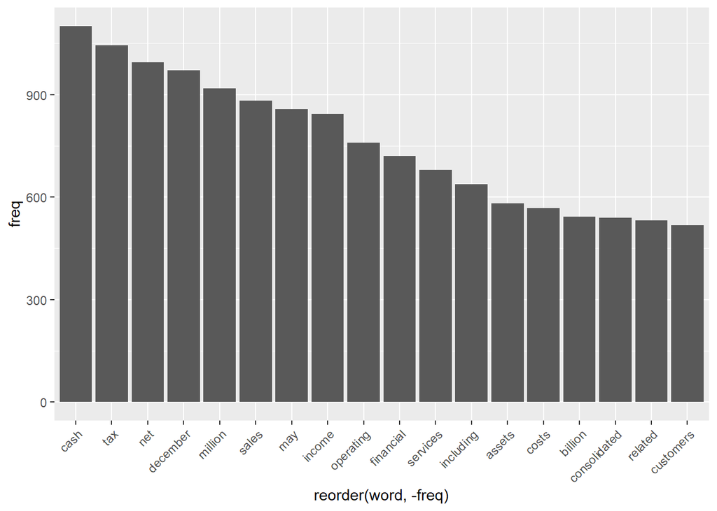

**Plot words that occur at least 25 times**

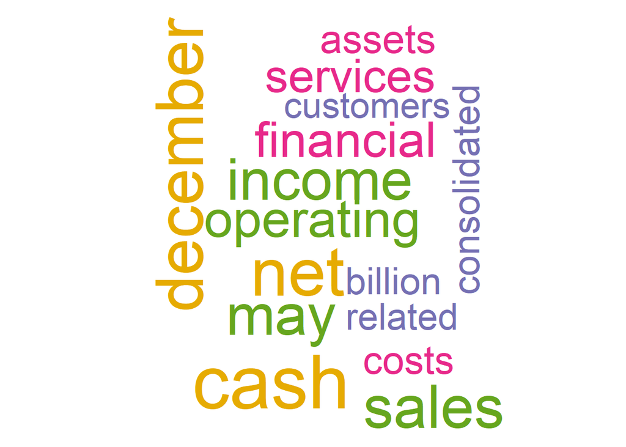

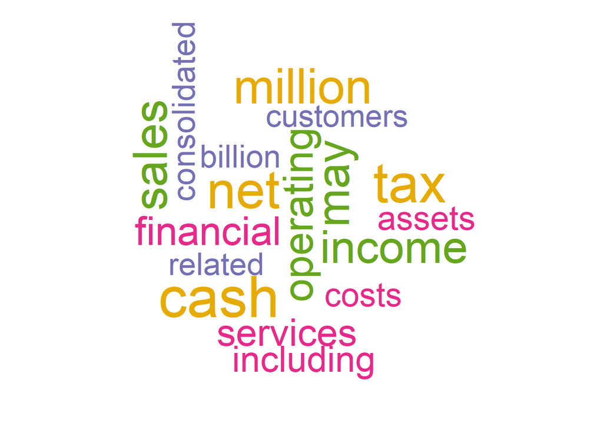

**Clustering**

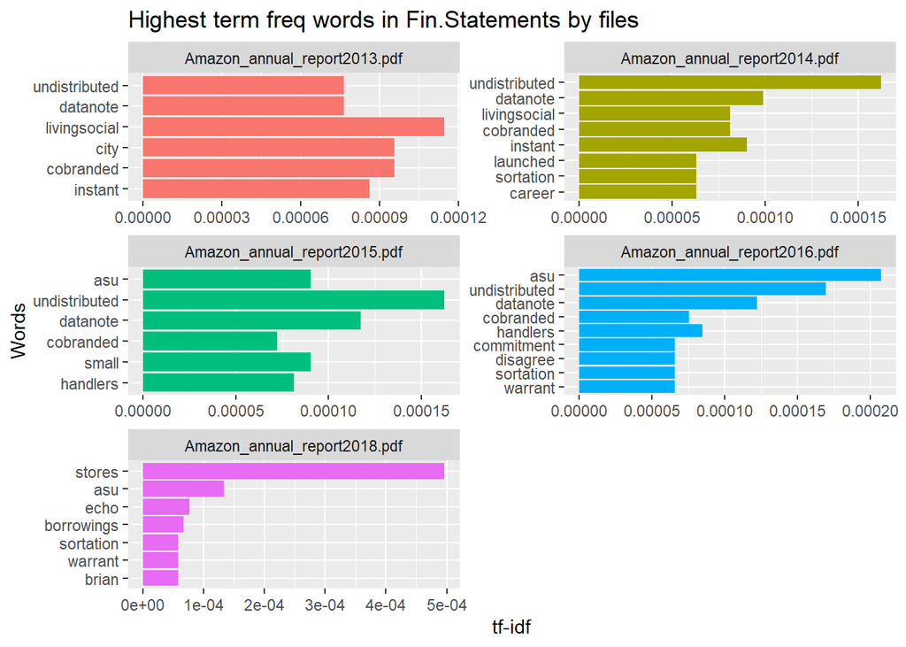

```
## clusters_
##    1    2    3    4
## 2112  587  220   26
```

[output not shown]

[output cut: 1909 more lines]

[output not shown]

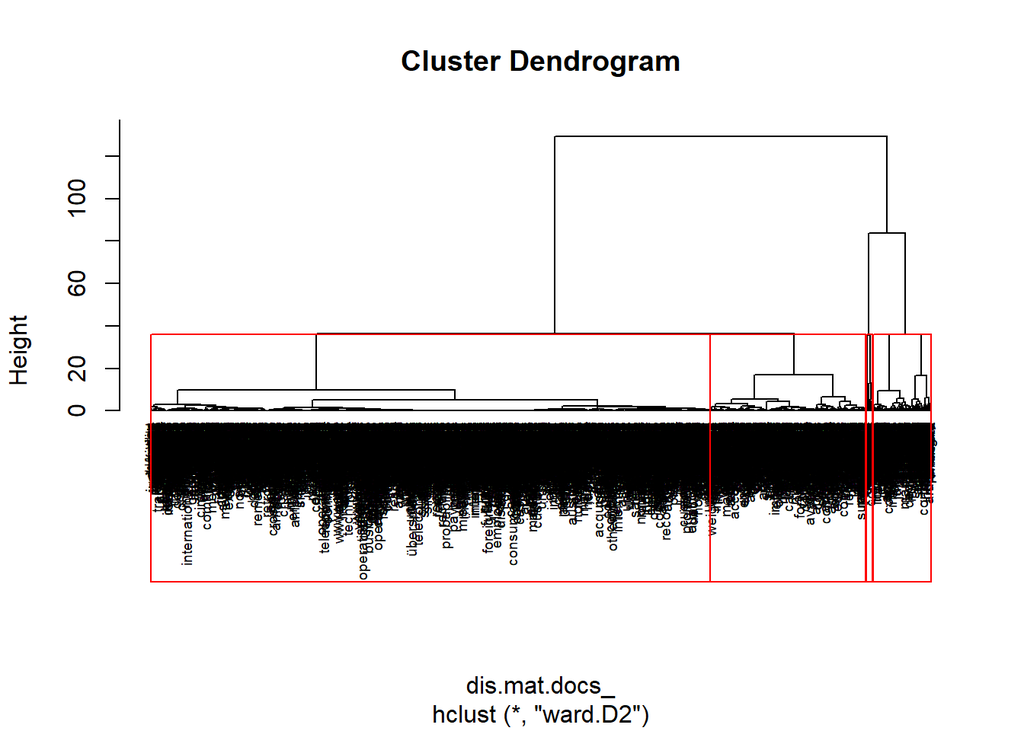

## 6.2 Facebook

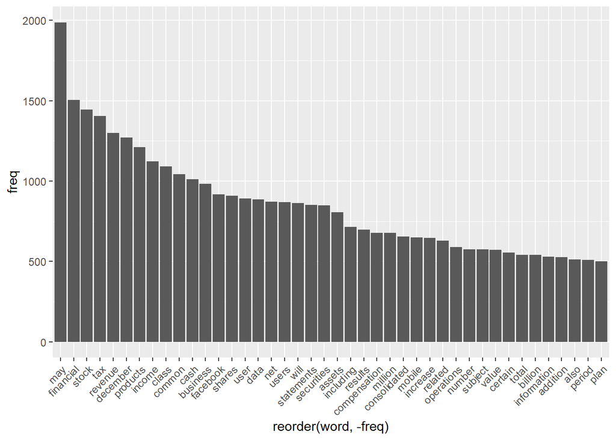

**Plot words that occur at least 25 times**

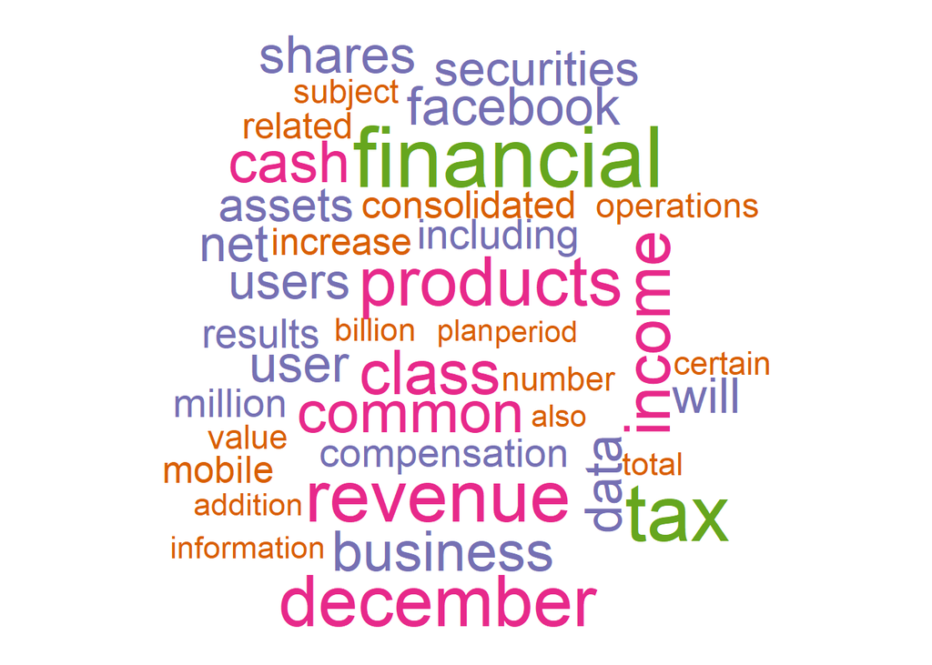

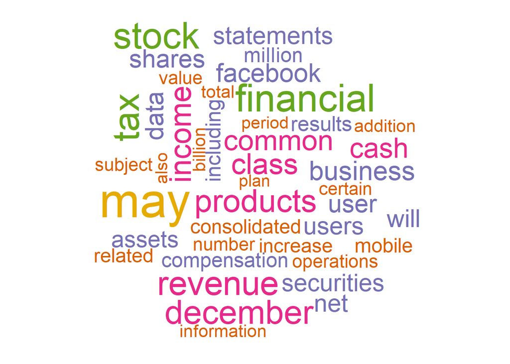

**Clustering**

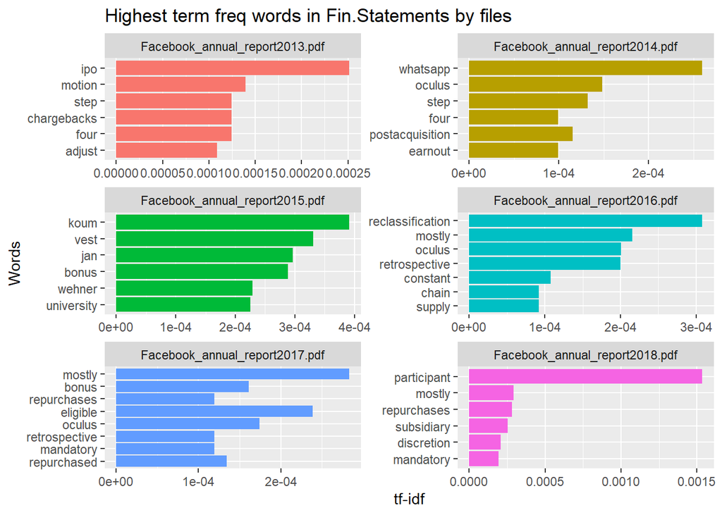

```
## clusters_
##    1    2    3    4
## 2556   84  134   25
```

[output not shown]

[output cut: 1811 more lines]

[output not shown]

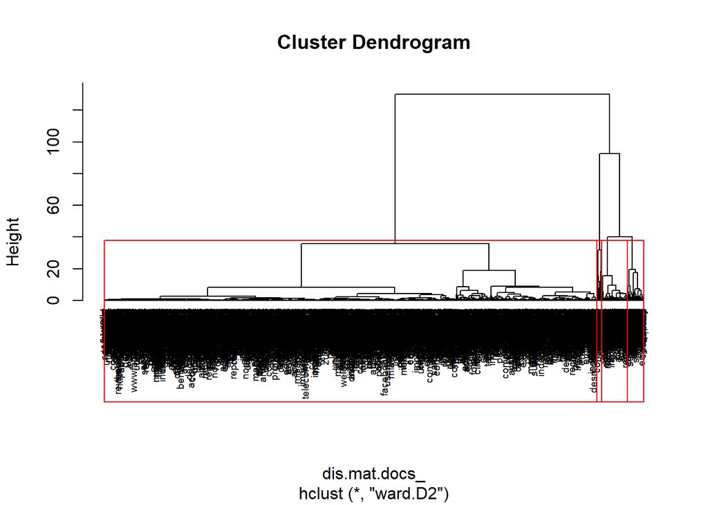

## 6.3 Fitbit

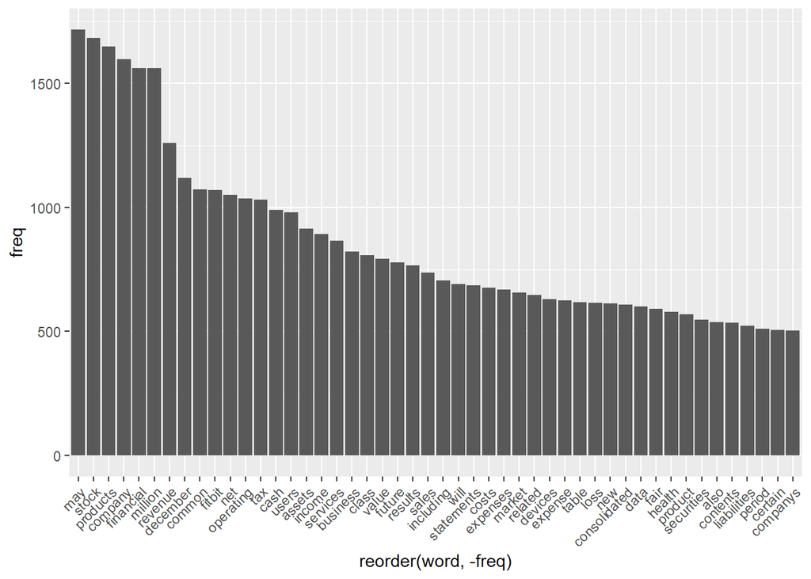

**Plot words that occur at least 25 times**

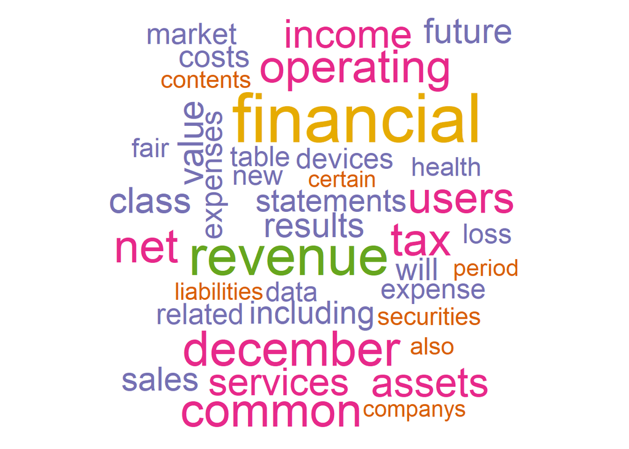

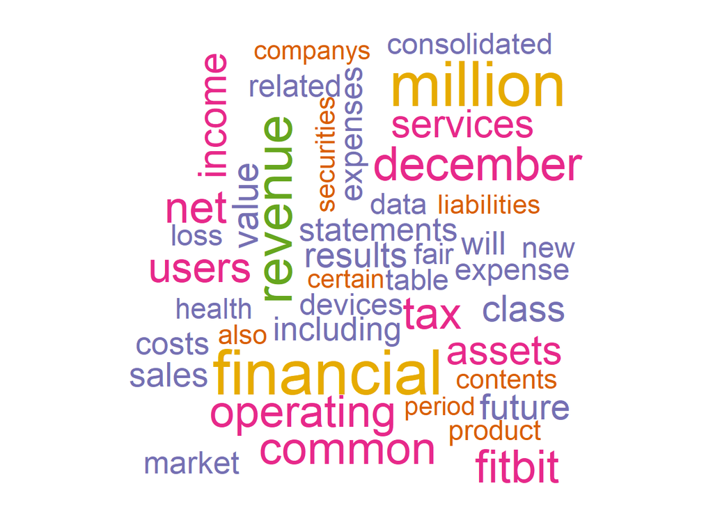

**Clustering**

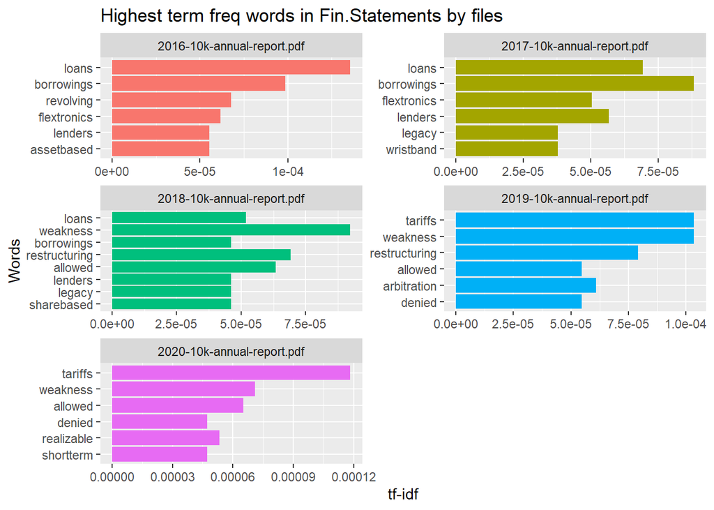

```
## clusters_
##    1    2    3    4
##  364 2828   46   15
```

[output not shown]

[output cut: 2115 more lines]

[output not shown]

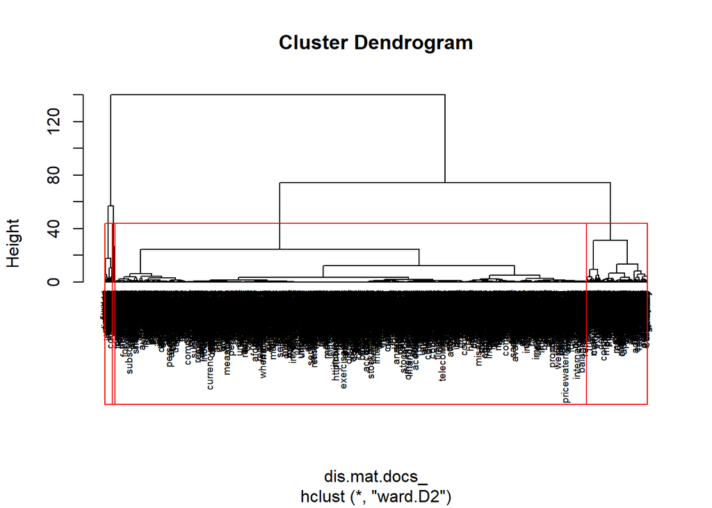

## 6.4 Intel Corporation

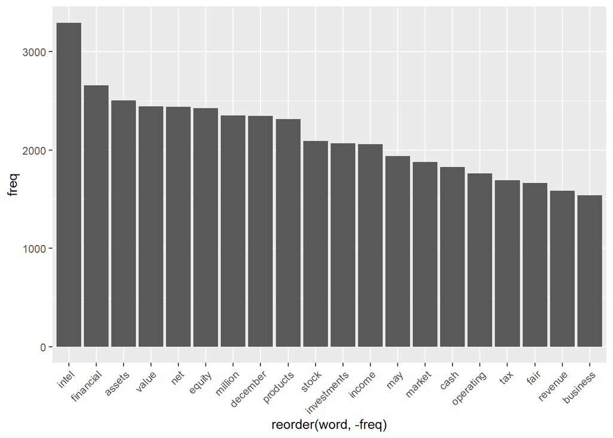

**Plot words that occur at least 25 times**

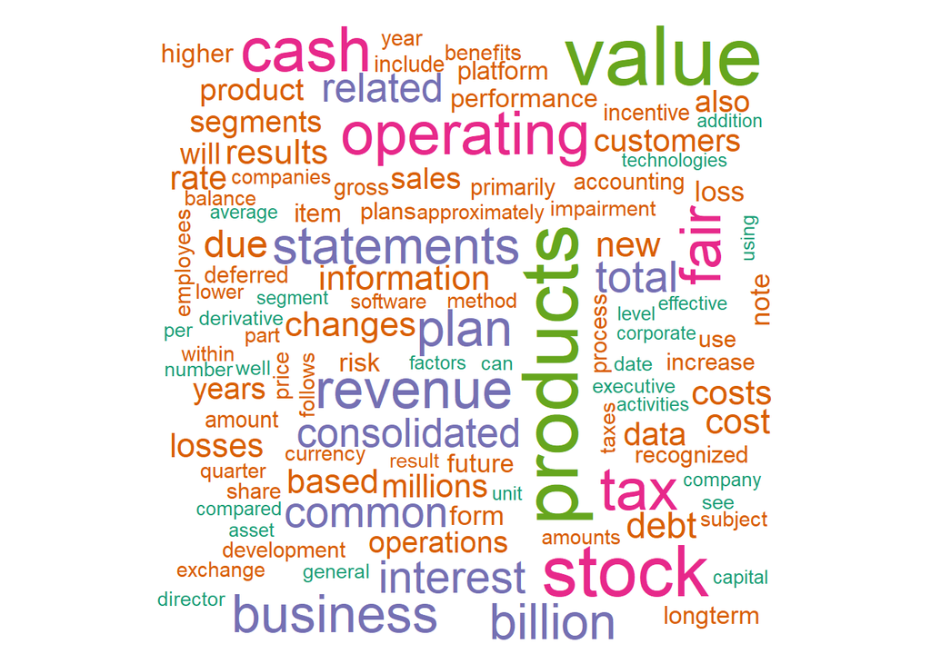

**Plot the 100 most frequently used works**

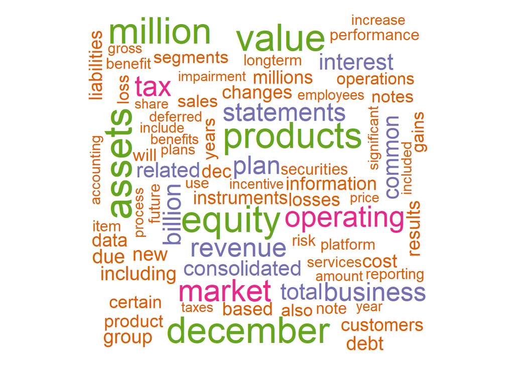

**Clustering**

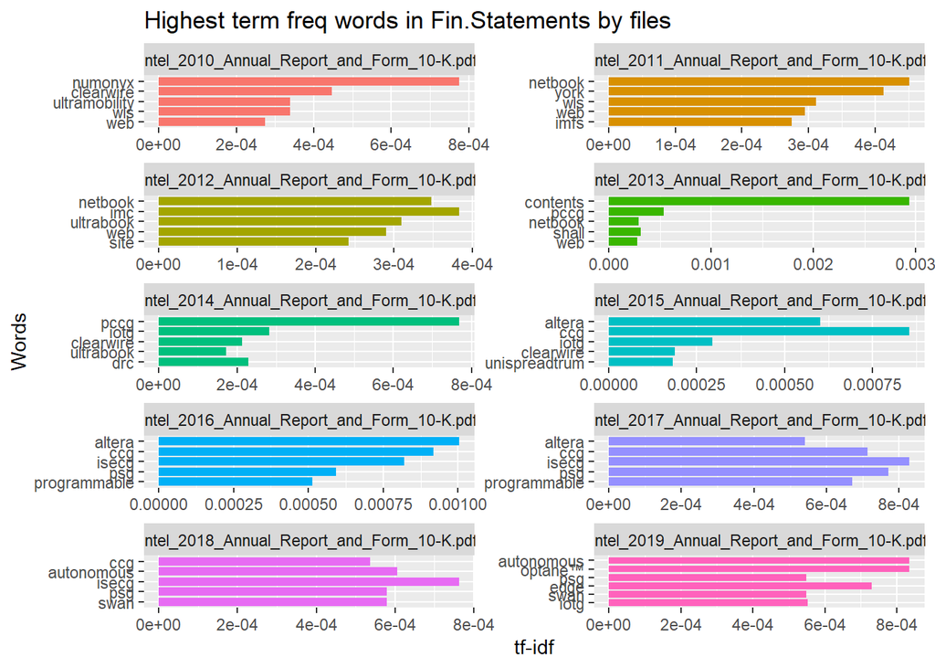

```
## clusters_
##    1    2    3    4
## 3365  733  157   21
```

[output not shown]

[output cut: 4221 more lines]

[output not shown]

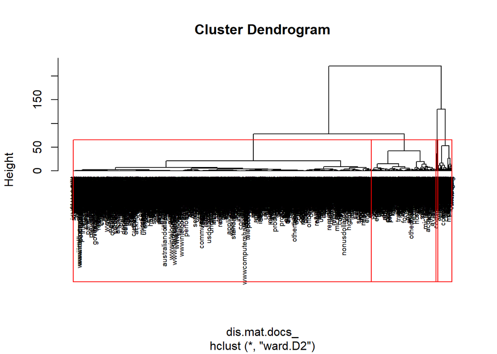

## 6.5 Netflix

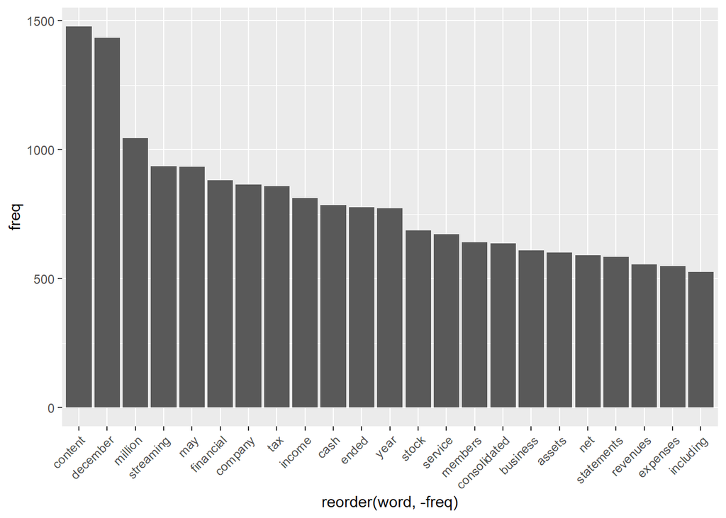

**Plot words that occur at least 25 times**

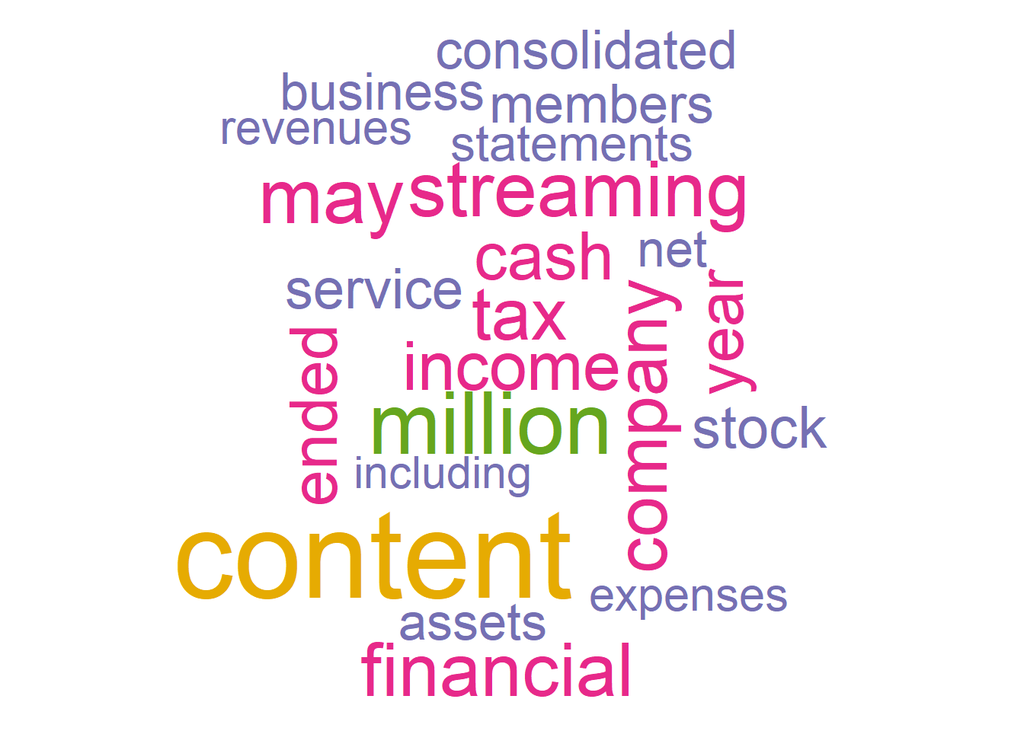

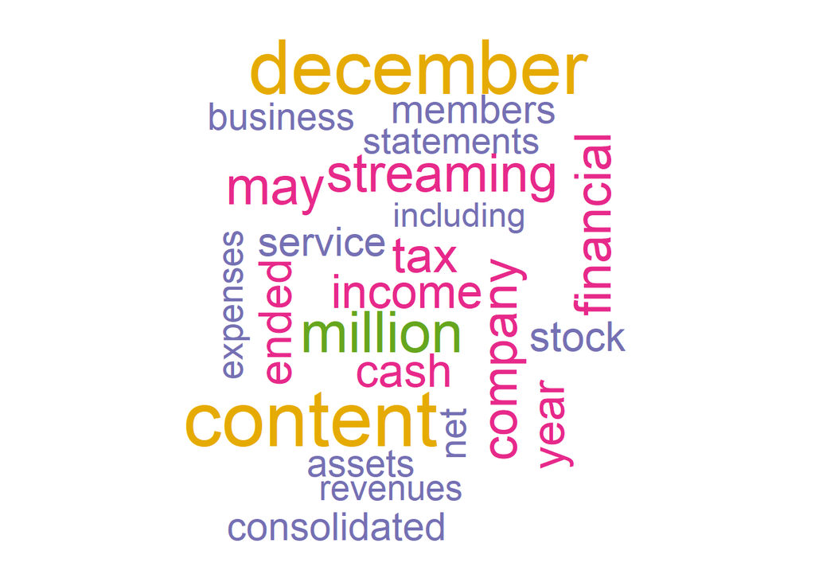

**Clustering**

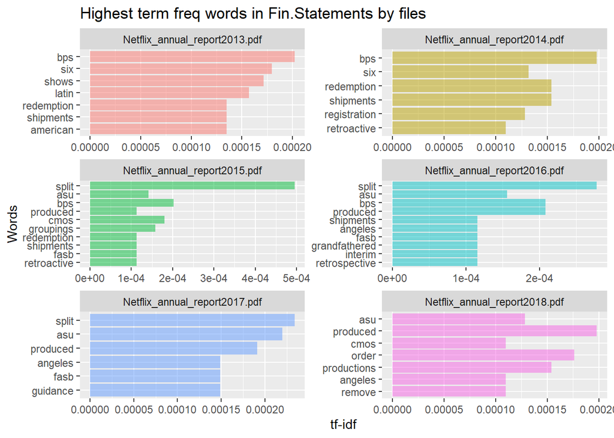

```
## clusters_
##    1    2    3    4
## 2212  179   21    2
```

[output not shown]

[output cut: 2359 more lines]

[output not shown]

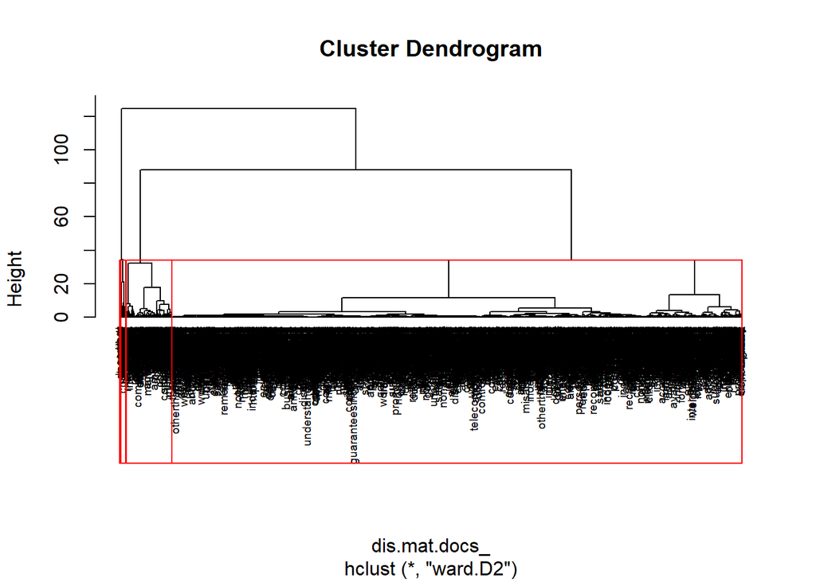

# 7 References

Avi, Jani, S., & Bidkar, C. (2019, March 29). The Fitbit Story - How It Scripted Wearable Tech’s Biggest Success Story. Retrieved from https://techstory.in/the-fitbit-story-how-it-scripted-wearable-techs-biggest-success-story/

Pai, A. (2015, December 1). Fitbit spent at least $17.8M to acquire FitStar. Retrieved from https://www.mobihealthnews.com/41972/fitbit-spent-at-least-17-8m-to-acquire-fitstar

https://www.tidytextmining.com/

https://rstudio-pubs-static.s3.amazonaws.com/265713_cbef910aee7642dc8b62996e38d2825d.html

http://www.sthda.com/french/wiki/text-mining-et-nuage-de-mots-avec-le-logiciel-r-5-etapes-simples-a-savoir

https://rpubs.com/tsholliger/301914